# Prediction Assignment Writeup

Manjari singh

2024-08-26

```r
# Load the necessary libraries
library(caret)
library(randomForest)
library(rpart)
```

```r
library(lattice)
library(ggplot2)
library(rpart.plot)
library(RColorBrewer)
```

# Reading train and test data

```r
require(data.table)
```

```r
url_train <- "https://d396qusza40orc.cloudfront.net/predmachlearn/pml-training.csv"
train <- read.csv(url(url_train), na.strings = c("NA",""))
```

### Partitioning: Split the dataset into a 80% training and 20% probing dataset.

```r
set.seed(2345)
inTrain <- createDataPartition(train$classe, p=0.8, list = FALSE)
data_train <- train[inTrain, ]
data_traintest <- train[-inTrain, ]
```

```r
dim(data_train)
```

```
## [1] 15699   160
```

```r
dim(data_traintest)
```

```
## [1] 3923  160
```

### Data cleaning: our data has both large number of NA values as well as near-zero-variance (NZV) variables. lets remove them in following steps

```r
nzv_var <- nearZeroVar(data_train)

data_train <- data_train[ , -nzv_var]
data_traintest  <- data_traintest [ , -nzv_var]
```

check dimension of clean data

```r
dim(data_train)
```

```
## [1] 15699   121
```

```r
dim(data_traintest)
```

```
## [1] 3923  121
```

Now we have only 121 columns (in contrast to 160 in original train_data)

#### Remove variables that are mostly NA. A threshlod of 95 % is selected.

```r
na_var <- sapply(data_train, function(x) mean(is.na(x))) > 0.95
data_train <- data_train[ , na_var == FALSE]
data_traintest  <- data_traintest [ , na_var == FALSE]

dim(data_train)
```

```
## [1] 15699    59
```

```r
dim(data_traintest)
```

```
## [1] 3923   59
```

we can see now the number of column is further reduced to 59(unlike 121 in previous step)

#### columns 1 to 5 are identification variables only. lets remove them also

```r
data_train <- data_train[ , -(1:5)]
data_traintest  <- data_traintest [ , -(1:5)]

dim(data_train)
```

```
## [1] 15699    54
```

```r
dim(data_traintest)
```

```
## [1] 3923   54
```

this step further reduces columns to 54. The number of variables for the analysis has been reduced from the original 160 down to 54

# prediction model on train data

[figure not shown]

```r
set.seed(1234)
fit_dt <- rpart(classe ~ ., data = data_train, method="class")
plot(fit_dt)
```

# model prediction on traintest data

```r
predict_dt <- predict(fit_dt, newdata = data_traintest, type="class")
conf_matrix_dt <- confusionMatrix(predict_dt, factor(data_traintest$classe))
conf_matrix_dt
```

```
## Confusion Matrix and Statistics
##
##           Reference
## Prediction    A    B    C    D    E
##          A 1010  166   29   65   43
##          B   41  412   57   24   73
##          C   11   55  543   82   52
##          D   40  106   35  436   96
##          E   14   20   20   36  457
##
## Overall Statistics
##
##                Accuracy : 0.7285
##                  95% CI : (0.7143, 0.7424)
##     No Information Rate : 0.2845
##     P-Value [Acc > NIR] : < 2.2e-16
##
##                   Kappa : 0.6548
##
##  Mcnemar's Test P-Value : < 2.2e-16
##
## Statistics by Class:
##
##                      Class: A Class: B Class: C Class: D Class: E
## Sensitivity            0.9050   0.5428   0.7939   0.6781   0.6338
## Specificity            0.8921   0.9384   0.9383   0.9155   0.9719
## Pos Pred Value         0.7692   0.6787   0.7308   0.6115   0.8355
## Neg Pred Value         0.9594   0.8954   0.9557   0.9355   0.9218
## Prevalence             0.2845   0.1935   0.1744   0.1639   0.1838
## Detection Rate         0.2575   0.1050   0.1384   0.1111   0.1165
## Detection Prevalence   0.3347   0.1547   0.1894   0.1817   0.1394
## Balanced Accuracy      0.8985   0.7406   0.8661   0.7968   0.8029
```

The predictive accuracy of the decision tree model is at 72.85 %.

Plot the predictive accuracy of the decision tree model.

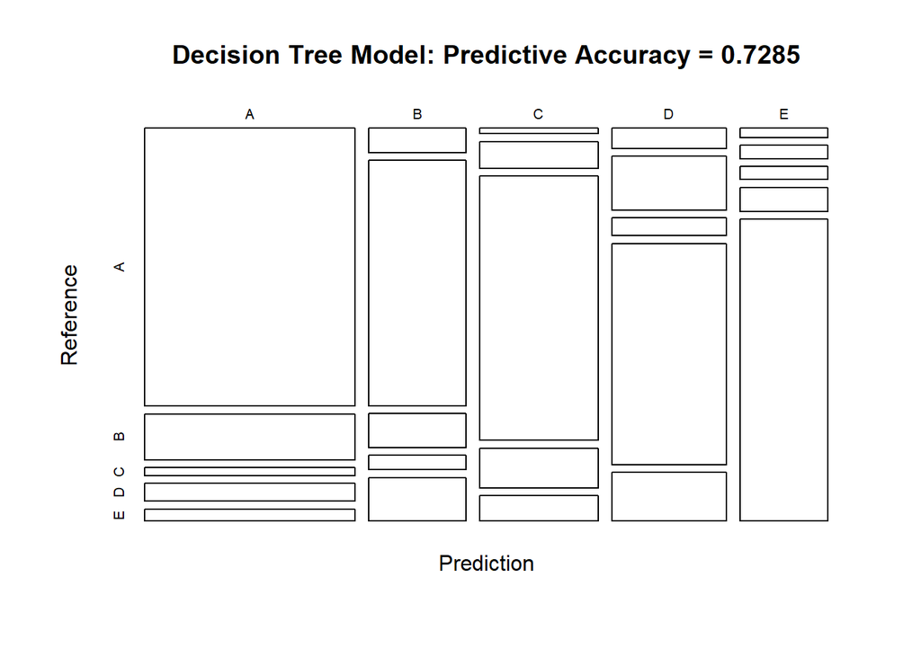

```r
plot(conf_matrix_dt$table, col = conf_matrix_dt$byClass,
     main = paste("Decision Tree Model: Predictive Accuracy =",
                  round(conf_matrix_dt$overall['Accuracy'], 4)))
```

# Random Forest Model

### training rf model

```r
set.seed(1234)
ctrl_RF <- trainControl(method = "cv", number = 5)
fit_RF  <- train(classe ~ ., data = data_train, method = "rf",
                  trControl = ctrl_RF, verbose = FALSE)
```

### prediction on test data

```r
predict_RF <- predict(fit_RF, newdata = data_traintest)
conf_matrix_RF <- confusionMatrix(predict_RF, factor(data_traintest$classe))
conf_matrix_RF
```

```
## Confusion Matrix and Statistics
##
##           Reference
## Prediction    A    B    C    D    E
##          A 1115    3    0    0    0
##          B    0  753    0    0    0
##          C    0    3  684    2    0
##          D    0    0    0  640    0
##          E    1    0    0    1  721
##
## Overall Statistics
##
##                Accuracy : 0.9975
##                  95% CI : (0.9953, 0.9988)
##     No Information Rate : 0.2845
##     P-Value [Acc > NIR] : < 2.2e-16
##
##                   Kappa : 0.9968
##
##  Mcnemar's Test P-Value : NA
##
## Statistics by Class:
##
##                      Class: A Class: B Class: C Class: D Class: E
## Sensitivity            0.9991   0.9921   1.0000   0.9953   1.0000
## Specificity            0.9989   1.0000   0.9985   1.0000   0.9994
## Pos Pred Value         0.9973   1.0000   0.9927   1.0000   0.9972
## Neg Pred Value         0.9996   0.9981   1.0000   0.9991   1.0000
## Prevalence             0.2845   0.1935   0.1744   0.1639   0.1838
## Detection Rate         0.2842   0.1919   0.1744   0.1631   0.1838
## Detection Prevalence   0.2850   0.1919   0.1756   0.1631   0.1843
## Balanced Accuracy      0.9990   0.9960   0.9992   0.9977   0.9997
```

# training Generalized Boosted Model (GBM)

```r
set.seed(1234)
ctrl_GBM <- trainControl(method = "cv", number = 5)
fit_GBM  <- train(classe ~ ., data = data_train, method = "gbm",
                  trControl = ctrl_GBM, verbose = FALSE)
```

### prediction on test data

```r
predict_GBM <- predict(fit_GBM, newdata = data_traintest)
conf_matrix_GBM <- confusionMatrix(predict_GBM, factor(data_traintest$classe))
conf_matrix_GBM
```

```
## Confusion Matrix and Statistics
##
##           Reference
## Prediction    A    B    C    D    E
##          A 1114    9    0    1    0
##          B    1  735    6    4    1
##          C    0   15  678    2    0
##          D    1    0    0  636    5
##          E    0    0    0    0  715
##
## Overall Statistics
##
##                Accuracy : 0.9885
##                  95% CI : (0.9847, 0.9916)
##     No Information Rate : 0.2845
##     P-Value [Acc > NIR] : < 2.2e-16
##
##                   Kappa : 0.9855
##
##  Mcnemar's Test P-Value : NA
##
## Statistics by Class:
##
##                      Class: A Class: B Class: C Class: D Class: E
## Sensitivity            0.9982   0.9684   0.9912   0.9891   0.9917
## Specificity            0.9964   0.9962   0.9948   0.9982   1.0000
## Pos Pred Value         0.9911   0.9839   0.9755   0.9907   1.0000
## Neg Pred Value         0.9993   0.9924   0.9981   0.9979   0.9981
## Prevalence             0.2845   0.1935   0.1744   0.1639   0.1838
## Detection Rate         0.2840   0.1874   0.1728   0.1621   0.1823
## Detection Prevalence   0.2865   0.1904   0.1772   0.1637   0.1823
## Balanced Accuracy      0.9973   0.9823   0.9930   0.9936   0.9958
```

The predictive accuracy of the GBM model is 98.85 %

# Reading test data

```r
require(data.table)
url_test <- "https://d396qusza40orc.cloudfront.net/predmachlearn/pml-testing.csv"
test <- read.csv(url(url_test), na.strings = c("NA", ""))
```

```r
predict_test <- as.data.frame(predict(fit_GBM, newdata = test))
predict_test
```

```
##    predict(fit_GBM, newdata = test)
## 1                                 B
## 2                                 A
## 3                                 B
## 4                                 A
## 5                                 A
## 6                                 E
## 7                                 D
## 8                                 B
## 9                                 A
## 10                                A
## 11                                B
## 12                                C
## 13                                B
## 14                                A
## 15                                E
## 16                                E
## 17                                A
## 18                                B
## 19                                B
## 20                                B
```